# Hydrophobicity Scale Comparison

Tristan Sones-Dykes

31/07/23

### Summary

In this doc, we compare all of the hydrophobicity scales on [this](https://resources.qiagenbioinformatics.com/manuals/clcgenomicsworkbench/650/Hydrophobicity_scales.html) site.

```
## number of iterations= 197
## number of iterations= 199
## number of iterations= 144
## number of iterations= 75
## number of iterations= 11
## number of iterations= 184
## number of iterations= 149
```

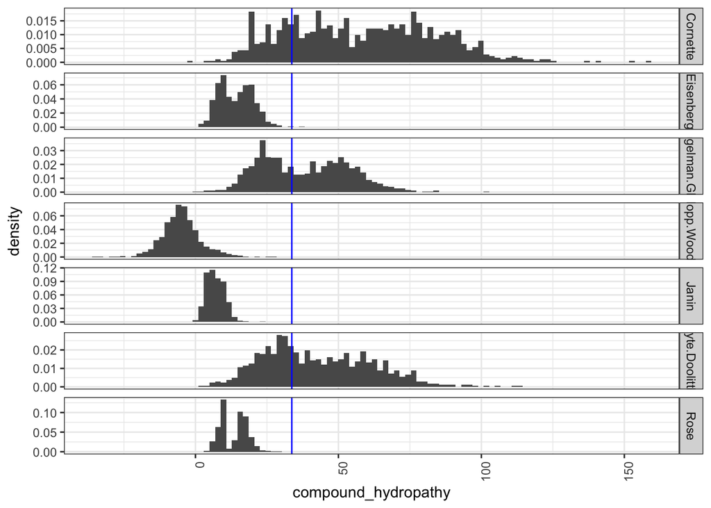

There is a wide range of distributions for the different scales. Some are bimodal, some are unimodal, some are skewed, some are symmetrical. Lets look at each distribution individually with their mixture models, intersections, and colour verified SRP independent proteins.

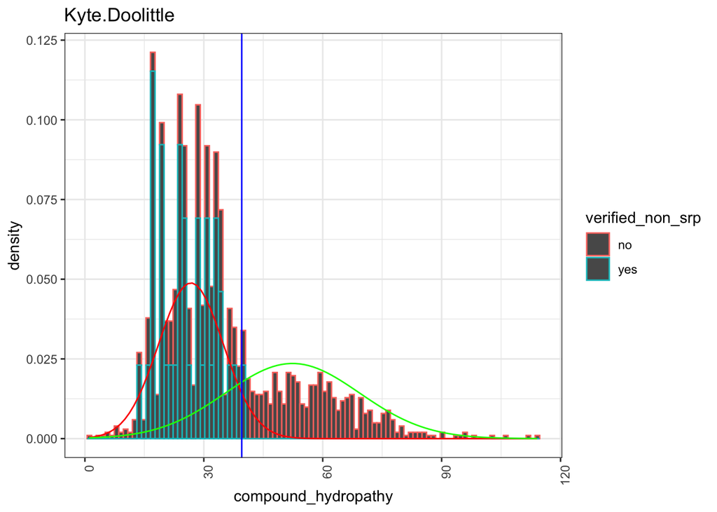

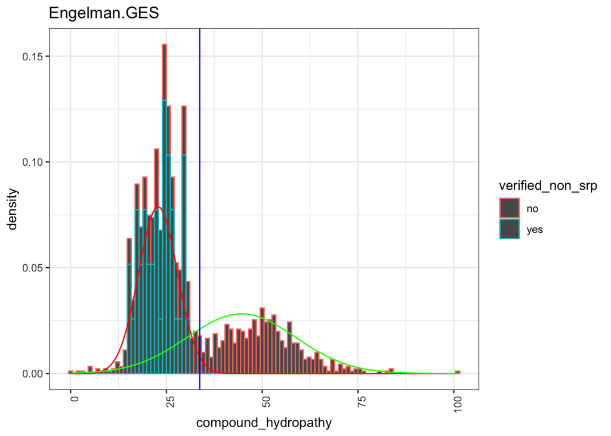

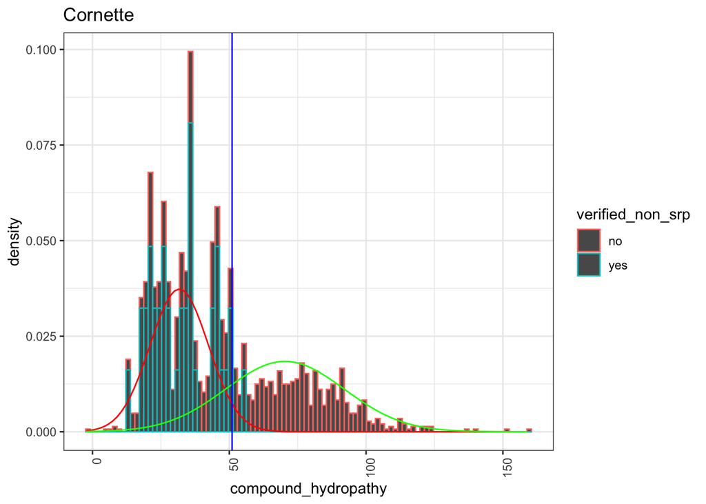

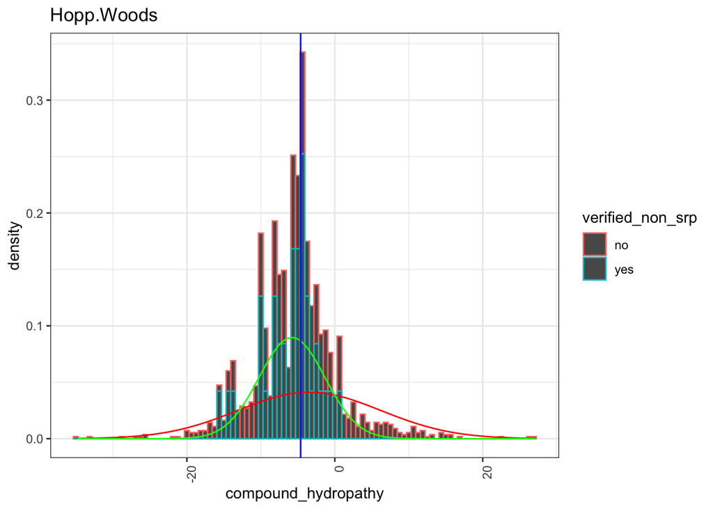

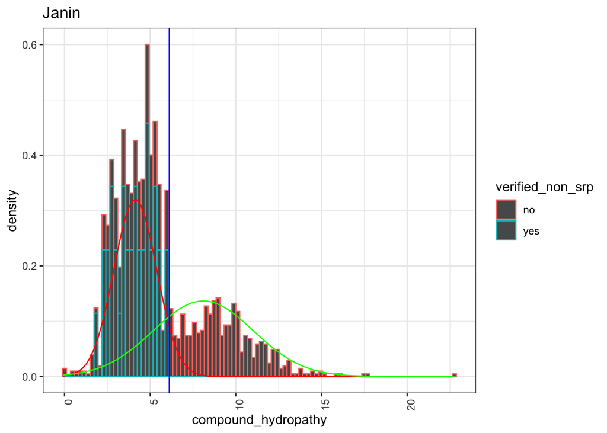

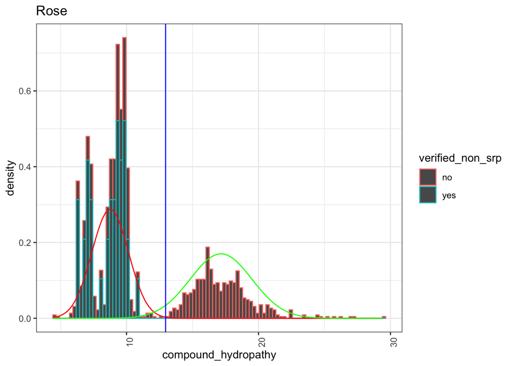

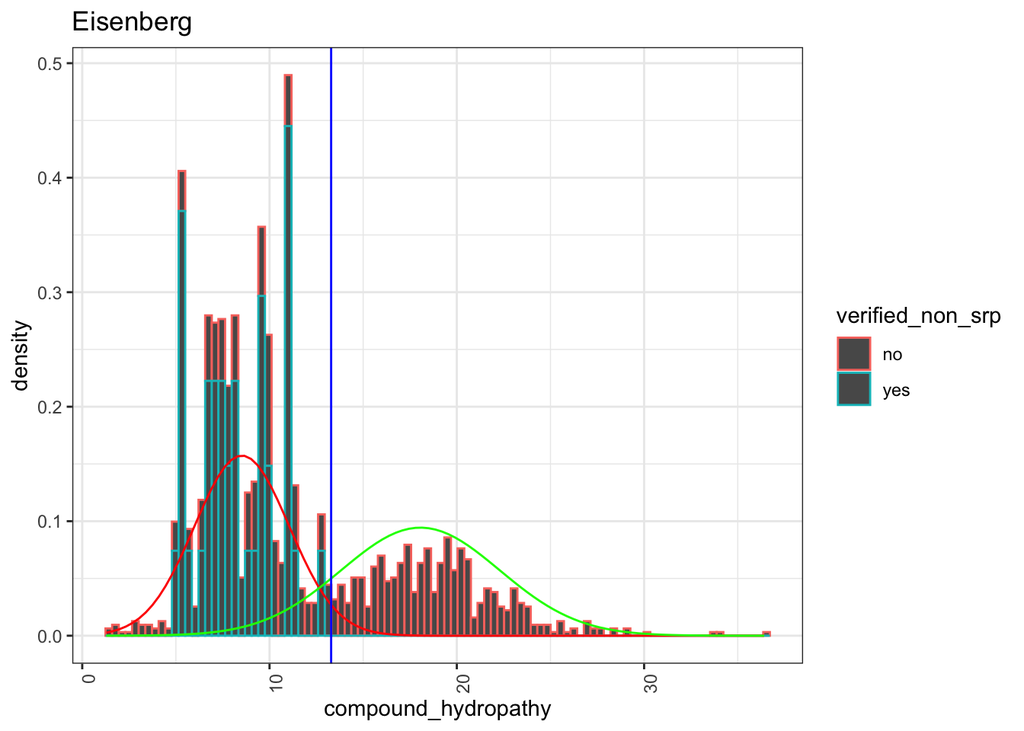

Rose has seemingly perfectly split the SRP and non-SRP into two groups, lets see if it does similar for other species.

```
## number of iterations= 151
```

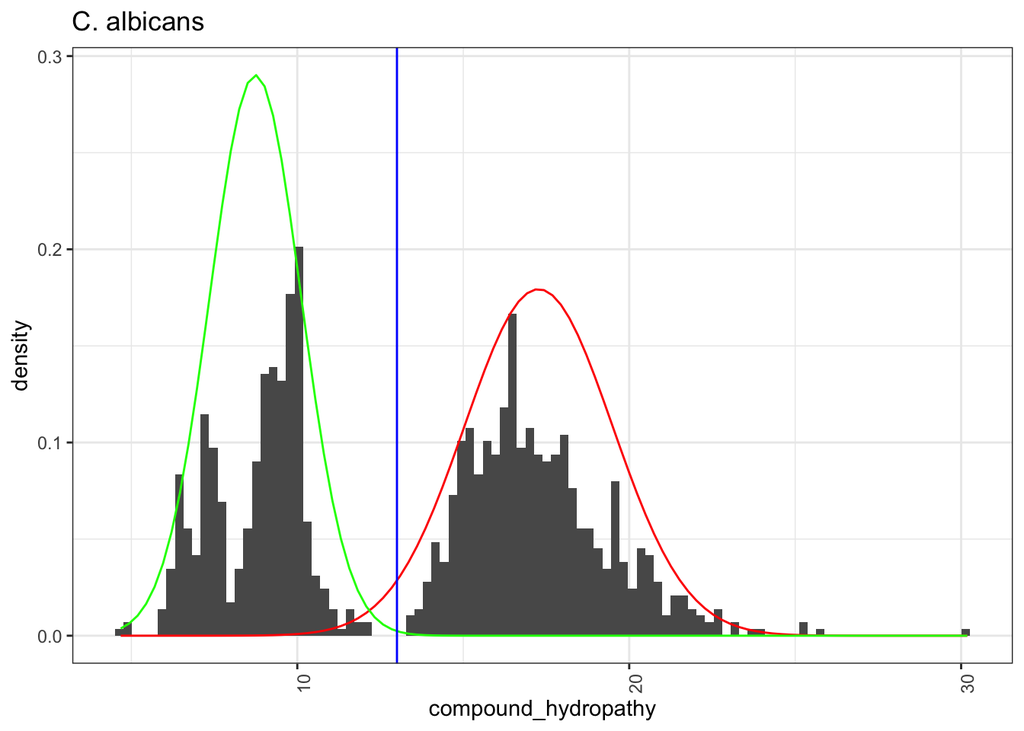

```
## number of iterations= 11
```

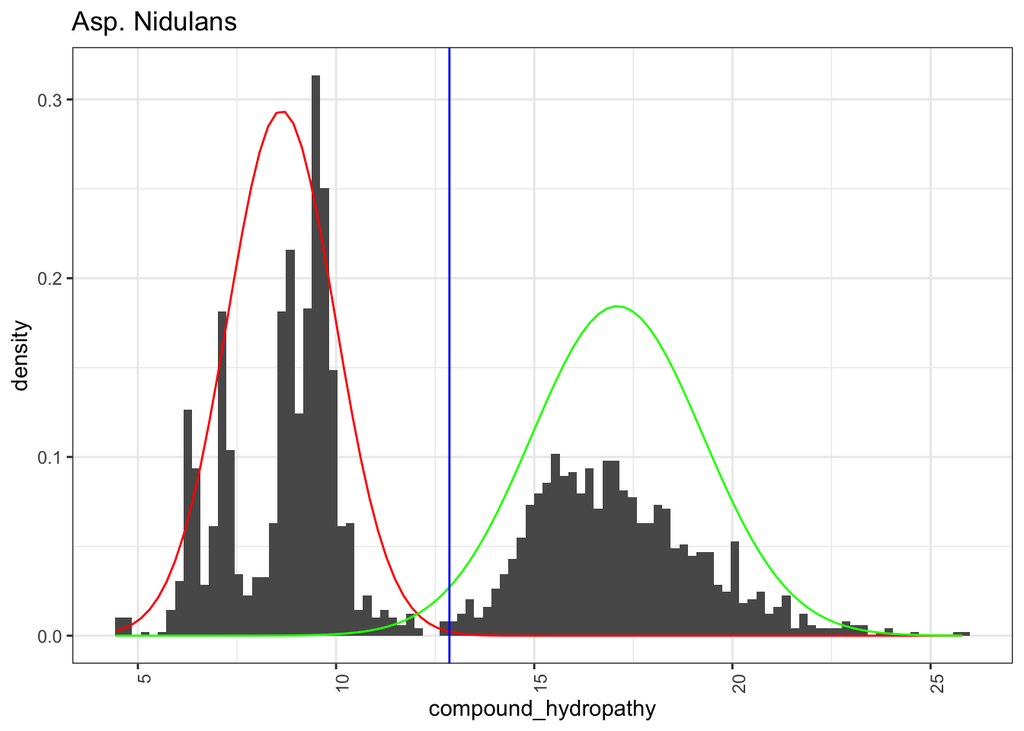

Looking at Rose and KD for screened and verified non SRP and verified SRP proteins.

```
## number of iterations= 97
```

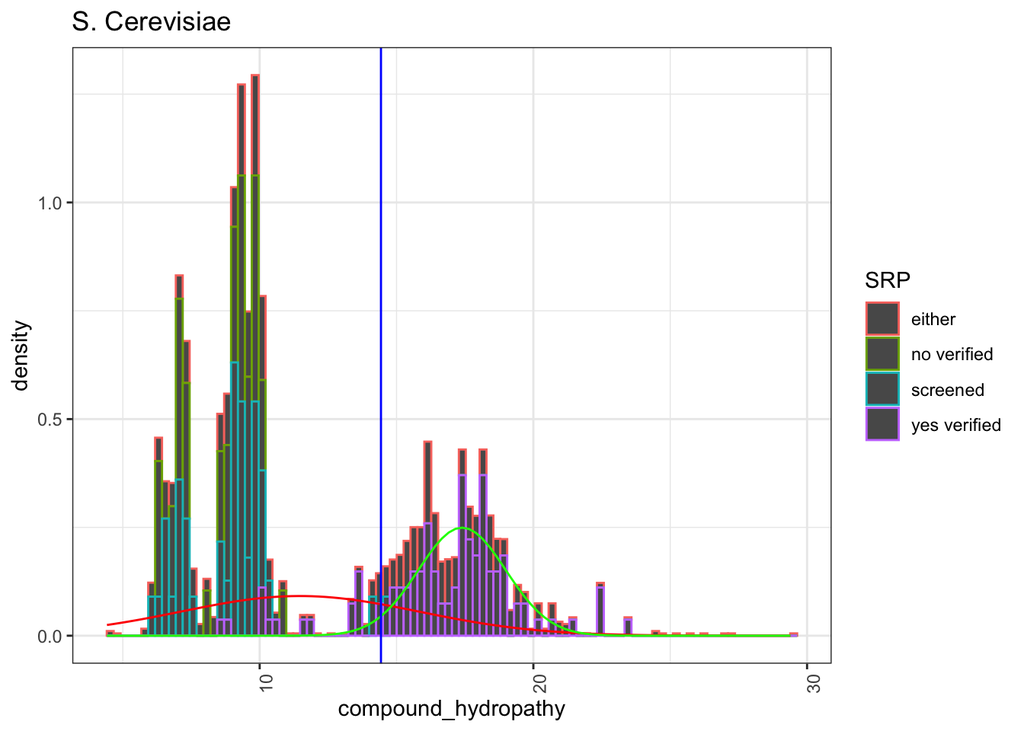

The split looks very good for both the yes and no populations, now it’s time to calculate the errors for both Kyte Doolittle and Rose.

```
## number of iterations= 13
```

```
## number of iterations= 197
```

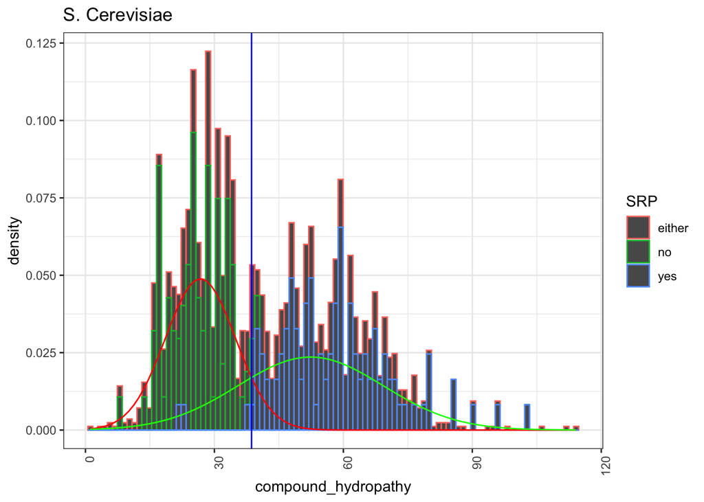

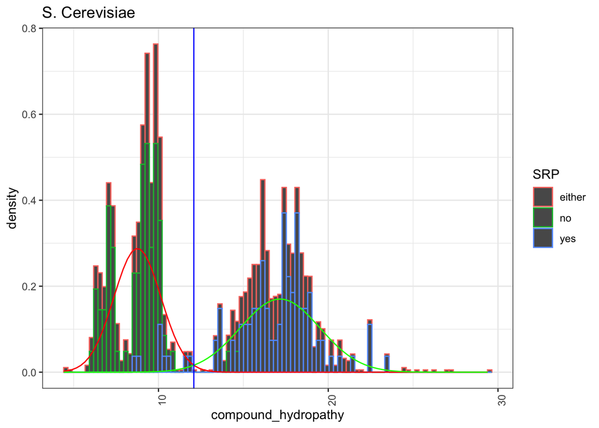

```
## [1] "Rose error: 0.0582010582010582"
```

```
## [1] "KD error: 0.037037037037037"
```

```
## [1] "Rose false positive: 0.024390243902439 Rose false negative: 0.0841121495327103"
```

```
## [1] "KD false positive: 0.0365853658536585 KD false negative: 0.0373831775700935"
```

The errors are very similar for both scales, but Rose has a lower false positive and higher false negative rate. You can see the small cluster of SRP proteins that are at the bottom of the left mode.

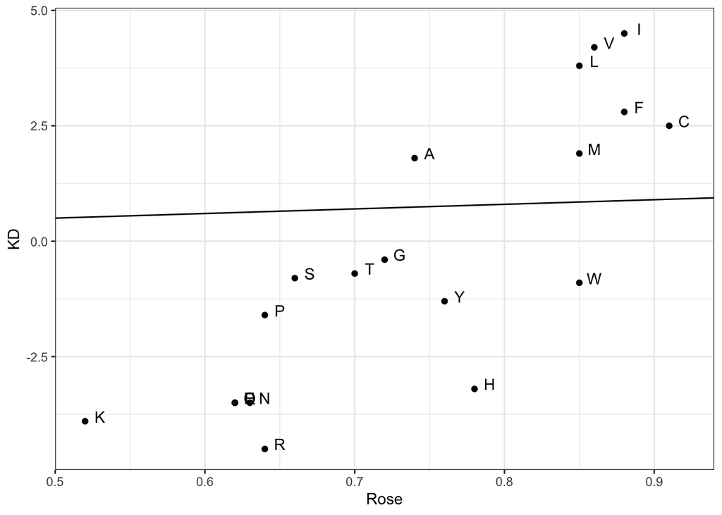